# Part II - Communicate Data Findings

## by Otiengo Philip

## Investigation Overview

The main feature of interest from the dataset is the Prosper Score which is custom risk score built using historical Prosper data. The score ranges from 1-10, with 10 being the best, or lowest risk score. Visualizations on how the other variables affects it and inferences to be made.

## Dataset Overview

The dataset is comprised of 81 variables and contains 113937 entries from *prosper.com* about the borrowers such as monthly income, is home owner or not etc and the loans borrowed such as rosper score,loan amount,repayment period etc.

## (Visualization 1)

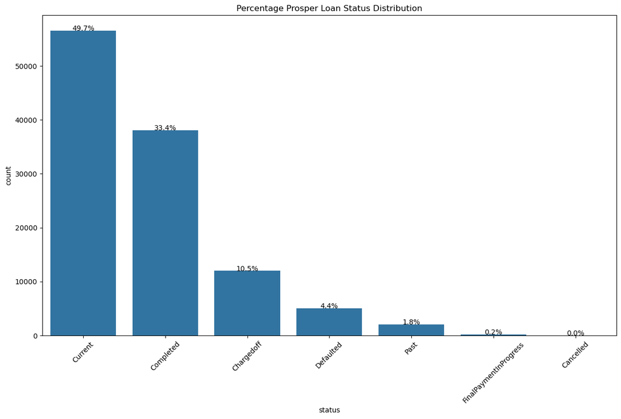

## (Visualization 2)

Prosper rating and estimated rating has a correlation r=-0.96, higher ratings means lower loss realised by the loans. This is a inverse in the correlation between the estimated loss and both Borrower Rate and Borrower APR as increase in the rates causing an increase in loss realised on the loans.

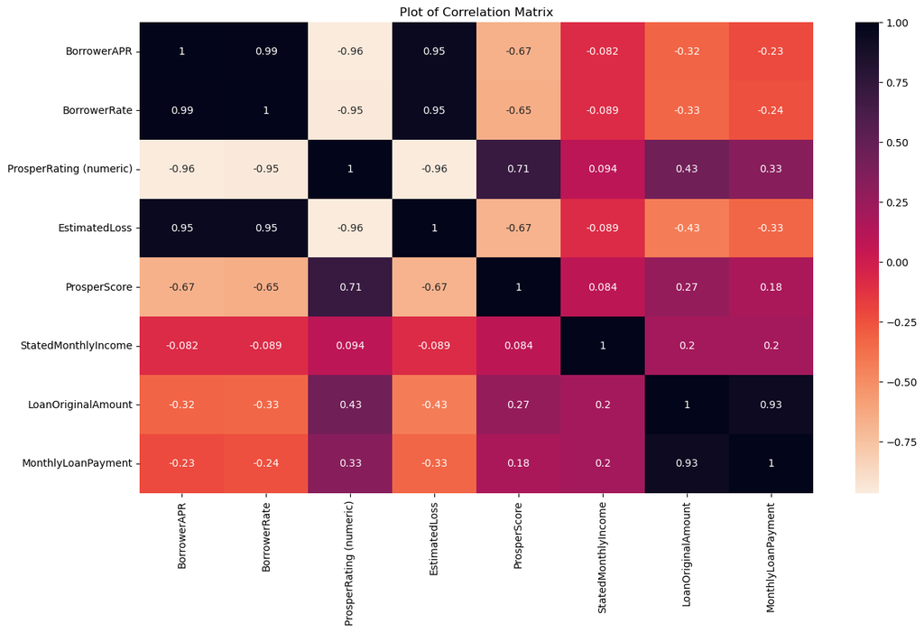

## (Visualization 3)

Loan amounts for employed and self employed are quite higher with Home owners taking much more than those with no homes. Retirees tends to take little home but generally owning a home guarantees much larger loans.

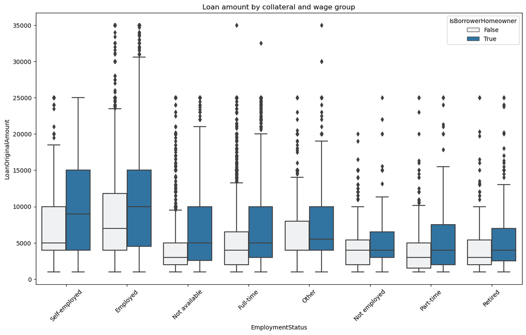